# IE 582 - Homework - 2

Elif Erdinç

October 26, 2018

## 1. Task 1

Same as the previous homework (HW 1), the soccer game information of English Premier League from 2011 to today and odd details for 27 bookmakers are taken as data sets. In this task, it is aimed to understand if over/under 2.5 game results can be estimated from the odds using Principal Component Analysis (PCA) and Multidimentional Scaling (MDS) methods.

### 1.1. Task 1.a

In this task, 5 different bookmakers (Pinnacle, bet365, bwin, ComeOn, Youwin) are selected. The over/under odds are filtered for total handicap of 2.5. Odds for the other bet types are also considered. The odd files are sorted by date and the final odds for the same matchId and odd type are taken. For each game, feature matrix of the odds for 5 selected bookmakers are created.

Meanwile, from the match data, the information on the game outcomes larger and lower than 2.5 is extracted and numarates so that 0 indicates outcome with lower than 2.5 and 1 as higher than 2.5.

These two information plots are converted into wide table data format and merged as a final data table to perform all PCA and MDS calculations. PCA and MDS with Euclidean and Manhattan distance methods are applied on the data sets for 5 bookmakers. Ther results and the related discussions are given below.

The **Figures 1, 5, 9 , 13, and 17** show the variances of principal components in descending order for 5 bookmakers. For example in Pinnacle case (Figure 1), as first principal component explains the all properties in 44%, second principal component explains only 25% of that. Therefore, in such a dimension reduction problems,taking at least two of the principle components will make more sense.

An eigenvalue is a number, telling you how much variance there is in the data in that direction, in the example above the eigenvalue is a number telling us how spread out the data is on the line. The eigenvector with the highest eigenvalue is therefore the principal component. In **Figures 2, 6, 10 , 14, and 18**, distribution of eigenvectors are shown as red arrows. The eigenvectors with higher magnitutes are more effective on explaining the data. Moreover, the closer eigenvectors in plot, the more similarity in representing the data.

**Figures 3, 7, 11 , 15, and 19** shows how over/under 2.5 results can be explained in PCA plot. As can be seen all these plots, there is no certain distinction based on colors. It can be concluded that PCA analysis is not good in estimation on over/under 2.5 match results. No distinct grouping is observed in these plots. If all compounds are used in the biplot, it may be more useful to look at the second and third principle components. This is simply because PCA captures the variation that exists in the compound data and you have chosen all compounds. However, most of them will show no significant change (i.e. little variation) and so some other underlying source of variation may be captured in the first dimension. These plots are also useful in identifying the outliers in the dataset.

**Figures 4, 8, 12 , 16, and 20** are the 3D representation of the PCA results.

#### 1.1.1. Pinnacle

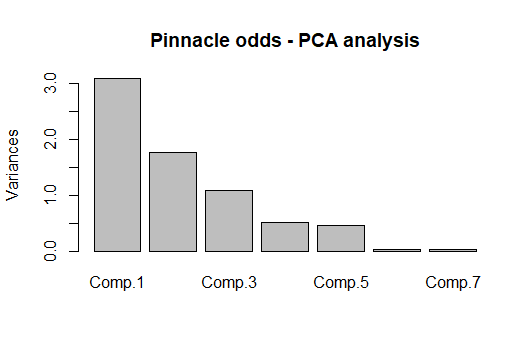

**Figure 1** - PCA on Pinnacle odds.

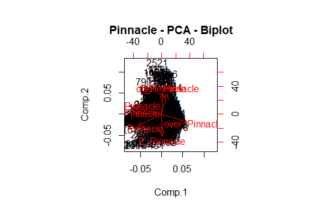

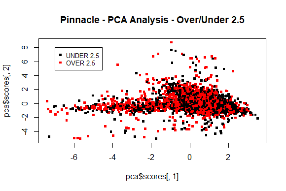

**Figure 3** - PCA on Pinnacle odds regarding game results of o/u 2.5 - 2D representation.

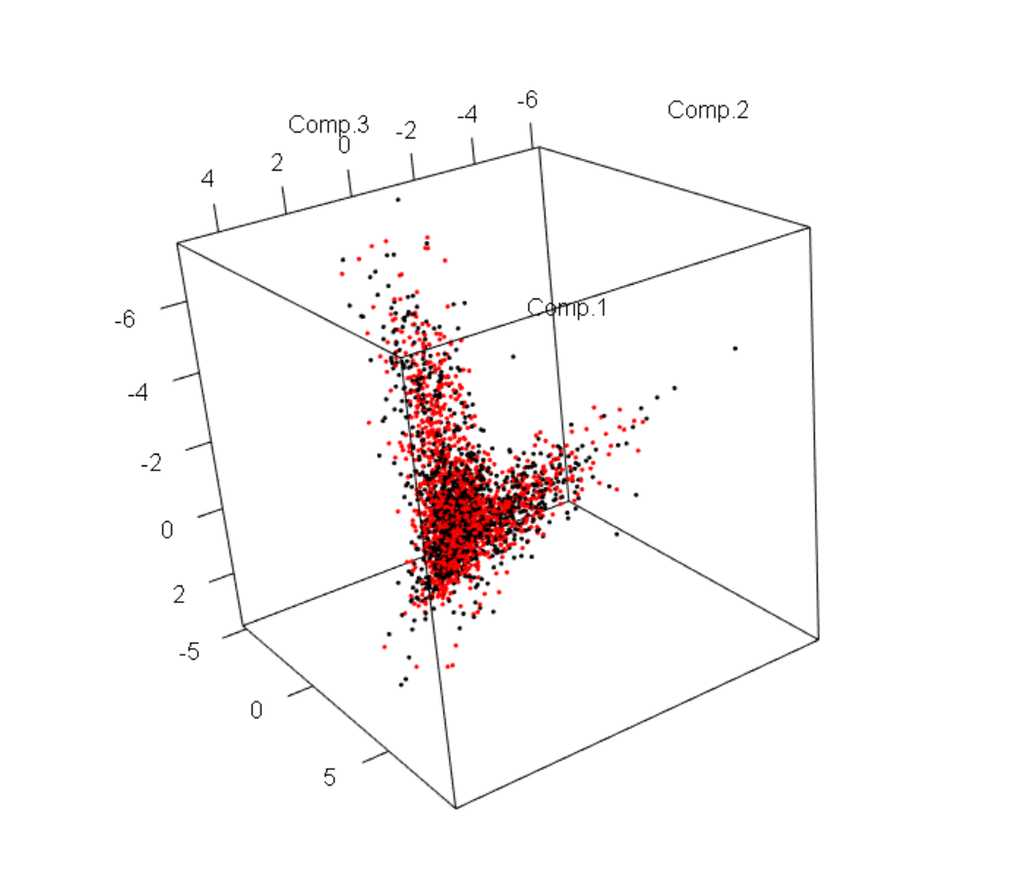

**Figure 4** - PCA on Pinnacle odds regarding game results of o/u 2.5 - 3D representation.

#### 1.1.2. Bet365

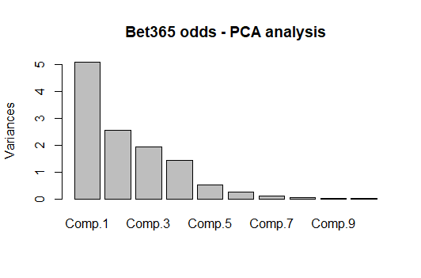

**Figure 5** - PCA on Bet365 odds.

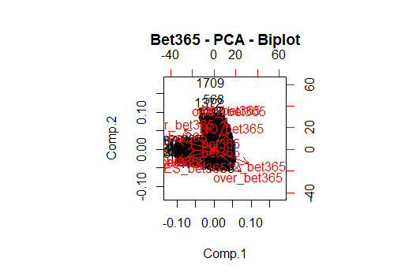

**Figure 6** - Biplot PCA for Bet365 odds.

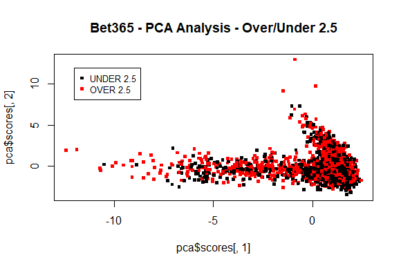

**Figure 7** - PCA on Bet365 odds regarding game results of o/u 2.5 - 2D representation.

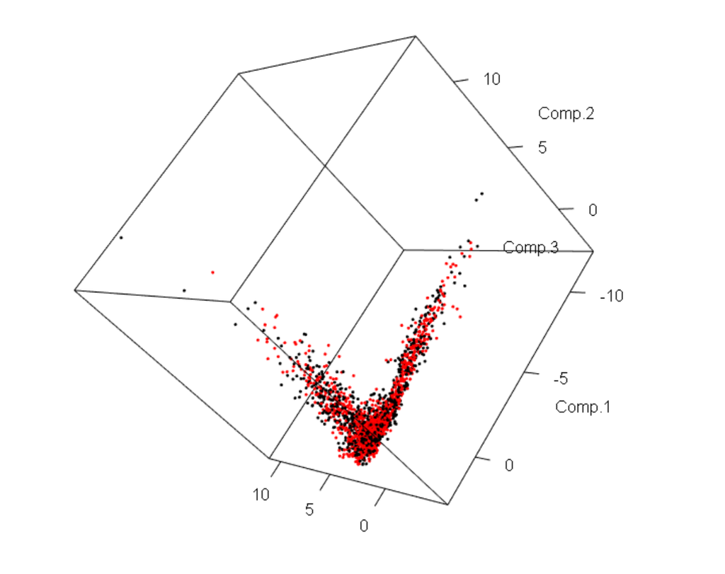

#### 1.1.3. BWin

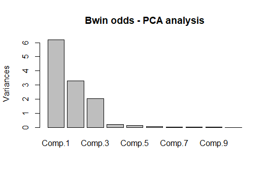

**Figure 9** - PCA analysis on Bwin odds.

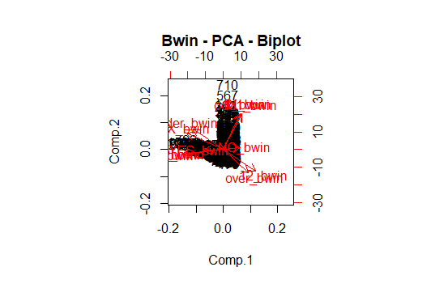

**Figure 10** - Biplot PCA for Bwin odds.

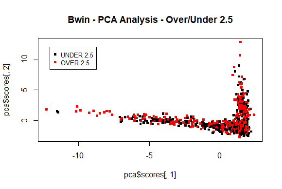

**Figure 11** - PCA analysis on Bwin odds regarding game results of o/u 2.5 - 2D representation.

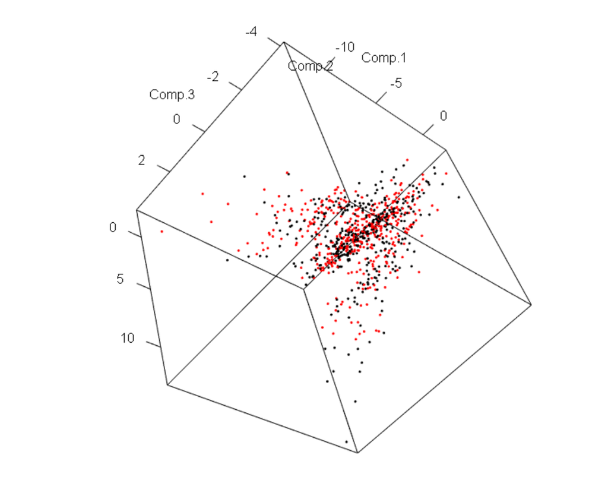

#### 1.1.4. Youwin

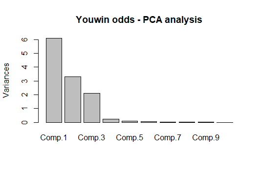

**Figure 13** - PCA analysis on Youwin odds.

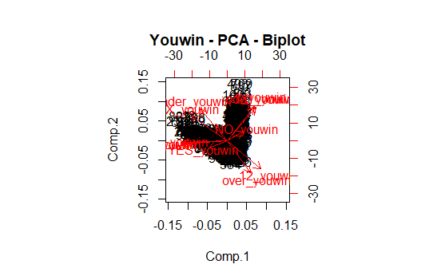

**Figure 14** - Biplot PCA for Youwin odds.

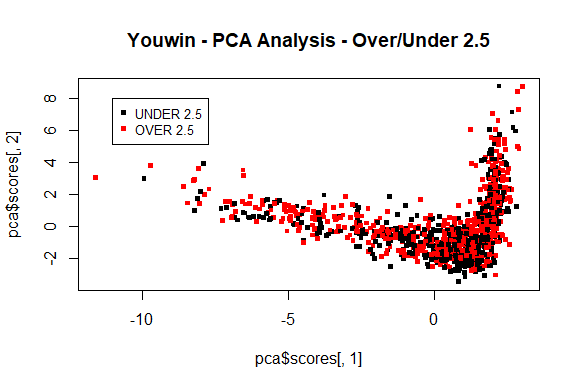

**Figure 15** - PCA analysis on Youwin odds regarding game results of o/u 2.5 - 2D representation.

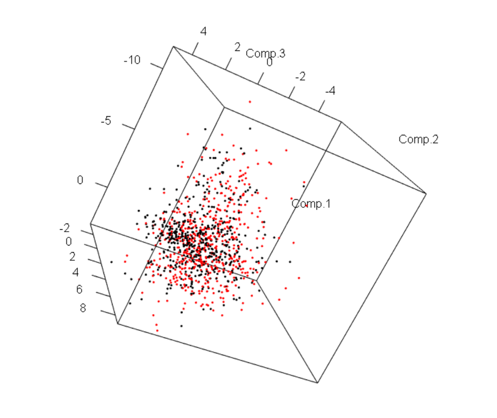

**Figure 16** - Youwin with higher reliability

#### 1.1.5. ComeOn

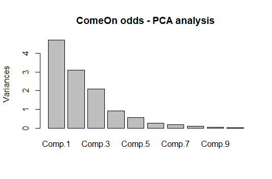

**Figure 17** - PCA analysis on ComeOn odds.

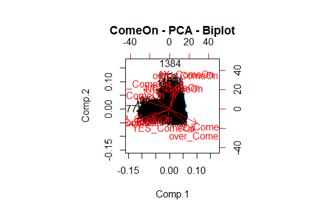

**Figure 18** - Biplot PCA for ComeOn odds.

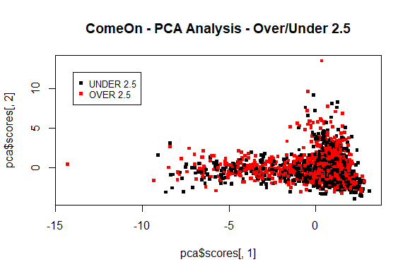

**Figure 19** - PCA analysis on ComeOn odds regarding game results of o/u 2.5 - 2D representation.

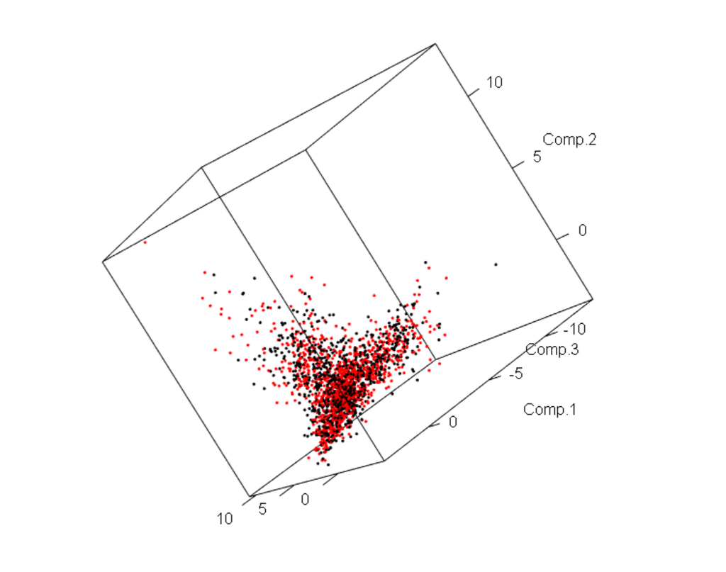

**Figure 20** - ComeOn with higher reliability

### 1.2. Task 1.b

The Euclidean distance is the ordinary (straight-line) distance between two points, wheras the Manhattan distance is defined as the sum of the lengths of the projections of the line segment between the points onto the coordinate axes. In **Figures 21 - 30**, Manhattan and Euclidean distance calculated MDS results are shown. There is no distinct difference between Manhattan and Euclidean distance methods. If data was scattering more, it would have been expected to see more robust results in Manhattan distance. However, our odd data scatters in a narrow range.

#### 1.2.1. Pinnacle

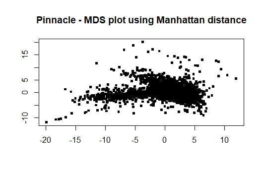

**Figure 21** - MSD plot with Manhattan distance calculation for Pinnacle odds.

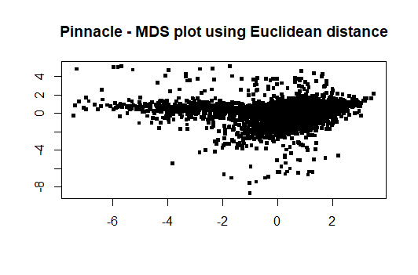

**Figure 22** - MSD plot with Euclidean distance calculation for Pinnacle odds.

#### 1.2.2. Bet365

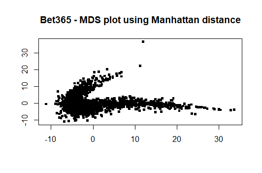

**Figure 23** - MSD plot with Manhattan distance calculation for Bet365 odds.

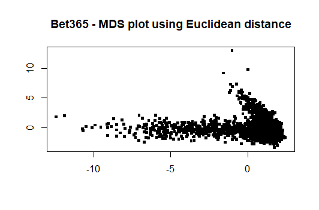

**Figure 24** - MSD plot with Euclidean distance calculation for Bet365 odds.

#### 1.2.3. Bwin

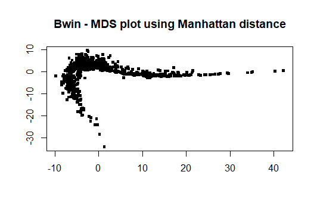

**Figure 25** - MSD plot with Manhattan distance calculation for Bwin odds.

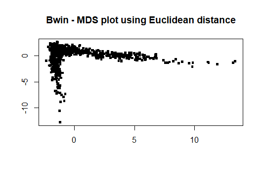

**Figure 26** - MSD plot with Euclidean distance calculation for Bwin odds.

#### 1.2.4. Youwin

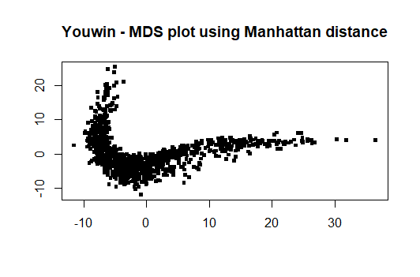

**Figure 27** - MSD plot with Manhattan distance calculation for Youwin odds.

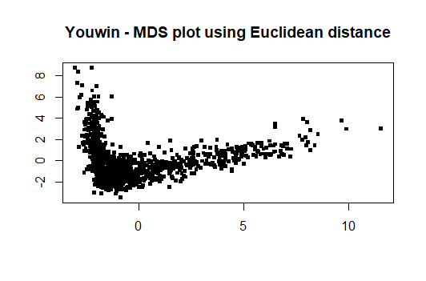

**Figure 28** - MSD plot with Euclidean distance calculation for Youwin odds.

#### 1.2.5. ComeOn

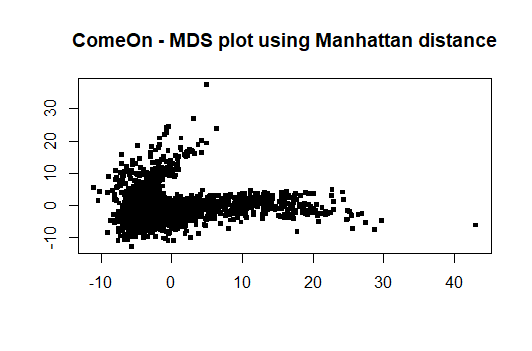

**Figure 29** - MSD plot with Manhattan distance calculation for ComeOn odds.

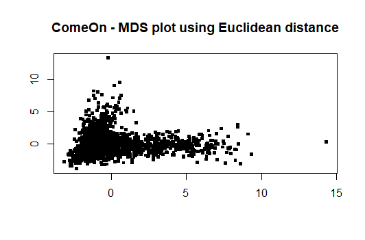

**Figure 30** - MSD plot with Euclidean distance calculation for ComeOn odds.

### 1.3. Task 1.c

PCA results are expected to be exactly same with MDS - Euclidean results. For example for bookmaker Bet365, they are found exactly same (Figures 7 and 24). However, for bookmaker Pinnacle these two plots (Figures 3 and 22) are found symmetrical on x=0 axis. This can be explained with the fact that each eigenvector can be defined with its orthogonal vectors. Probably, in two different calculations (PCA vs Euclidean), two orthogonal vectors are considered.

# 2. Task 2

In this task, the same PCA analysis is performed to understand match outcomes of home, tie, or away. As in Task 1, feature vector made of odd data is constructed. From match data, scores of each game is filtered in a way that home, tie, and away are represented as 1, 2, and 3 in “Outcomes” column.

#### 2.1. Pinnacle

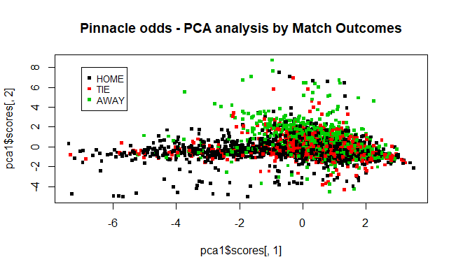

**Figure 31** - PCA analysis on Pinnacle odds regarding game outcomes (Home,Tie, Away) - 2D representation.

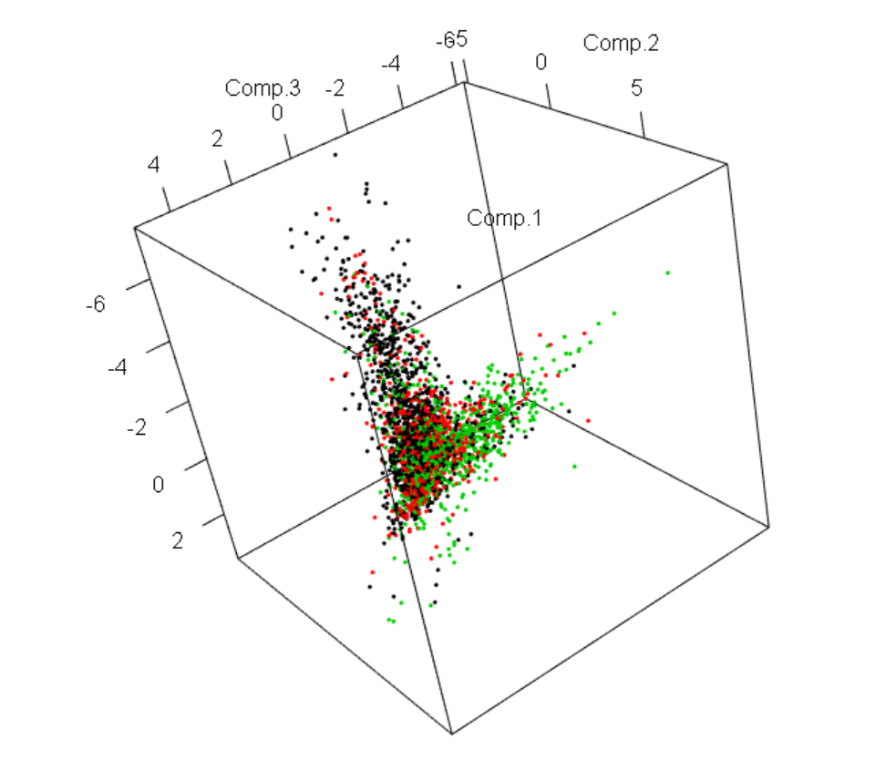

**Figure 32** - PCA analysis on Pinnacle odds regarding game outcomes (Home,Tie, Away) - 3D representation.